# Renewind

Importing librarires

```python
#Importing Data manupulation libraries
import numpy as np
import pandas as pd

#importing data visualisation libraries
import matplotlib.pyplot as plt
import seaborn as sns

#importing library to split dataset to train and test sets
from sklearn.model_selection import train_test_split

#for hyperparameter tuning
from sklearn.model_selection import GridSearchCV,RandomizedSearchCV

#for calculating metrics
from sklearn.metrics import recall_score,accuracy_score,f1_score,precision_score,confusion_matrix,classification_report,auc,roc_curve
from sklearn import metrics

# To help with model building
from sklearn.linear_model import LogisticRegression
from sklearn.tree import DecisionTreeClassifier
from sklearn.ensemble import AdaBoostClassifier,GradientBoostingClassifier,BaggingClassifier,RandomForestClassifier

from xgboost import XGBClassifier

#for handling missing data
from sklearn.impute import SimpleImputer

#to perform data Normalization
from sklearn.preprocessing import StandardScaler

from sklearn.model_selection import  StratifiedKFold, cross_val_score

from imblearn.over_sampling import SMOTE
from imblearn.under_sampling import RandomUnderSampler

from sklearn.pipeline import Pipeline

# To suppress warnings
import warnings
warnings.filterwarnings("ignore")
```

Loading the Dataset

```python
test=pd.read_csv("Test.csv.zip")
train=pd.read_csv("Train.csv.zip")
```

Data Overview

```python
test.shape
```

```
(5000, 41)
```

```python
train.shape
```

```
(20000, 41)
```

```python
test.head()
```

|  | V1 | V2 | V3 | V4 | V5 | V6 | V7 | V8 | V9 | V10 | ... | V32 | V33 | V34 | V35 | V36 | V37 | V38 | V39 | V40 | Target |
| --- | --- | --- | --- | --- | --- | --- | --- | --- | --- | --- | --- | --- | --- | --- | --- | --- | --- | --- | --- | --- | --- |
| 0 | -0.613489 | -3.819640 | 2.202302 | 1.300420 | -1.184929 | -4.495964 | -1.835817 | 4.722989 | 1.206140 | -0.341909 | ... | 2.291204 | -5.411388 | 0.870073 | 0.574479 | 4.157191 | 1.428093 | -10.511342 | 0.454664 | -1.448363 | 0 |
| 1 | 0.389608 | -0.512341 | 0.527053 | -2.576776 | -1.016766 | 2.235112 | -0.441301 | -4.405744 | -0.332869 | 1.966794 | ... | -2.474936 | 2.493582 | 0.315165 | 2.059288 | 0.683859 | -0.485452 | 5.128350 | 1.720744 | -1.488235 | 0 |
| 2 | -0.874861 | -0.640632 | 4.084202 | -1.590454 | 0.525855 | -1.957592 | -0.695367 | 1.347309 | -1.732348 | 0.466500 | ... | -1.318888 | -2.997464 | 0.459664 | 0.619774 | 5.631504 | 1.323512 | -1.752154 | 1.808302 | 1.675748 | 0 |
| 3 | 0.238384 | 1.458607 | 4.014528 | 2.534478 | 1.196987 | -3.117330 | -0.924035 | 0.269493 | 1.322436 | 0.702345 | ... | 3.517918 | -3.074085 | -0.284220 | 0.954576 | 3.029331 | -1.367198 | -3.412140 | 0.906000 | -2.450889 | 0 |
| 4 | 5.828225 | 2.768260 | -1.234530 | 2.809264 | -1.641648 | -1.406698 | 0.568643 | 0.965043 | 1.918379 | -2.774855 | ... | 1.773841 | -1.501573 | -2.226702 | 4.776830 | -6.559698 | -0.805551 | -0.276007 | -3.858207 | -0.537694 | 0 |

5 rows × 41 columns

```python
train.head()
```

|  | V1 | V2 | V3 | V4 | V5 | V6 | V7 | V8 | V9 | V10 | ... | V32 | V33 | V34 | V35 | V36 | V37 | V38 | V39 | V40 | Target |
| --- | --- | --- | --- | --- | --- | --- | --- | --- | --- | --- | --- | --- | --- | --- | --- | --- | --- | --- | --- | --- | --- |
| 0 | -4.464606 | -4.679129 | 3.101546 | 0.506130 | -0.221083 | -2.032511 | -2.910870 | 0.050714 | -1.522351 | 3.761892 | ... | 3.059700 | -1.690440 | 2.846296 | 2.235198 | 6.667486 | 0.443809 | -2.369169 | 2.950578 | -3.480324 | 0 |
| 1 | 3.365912 | 3.653381 | 0.909671 | -1.367528 | 0.332016 | 2.358938 | 0.732600 | -4.332135 | 0.565695 | -0.101080 | ... | -1.795474 | 3.032780 | -2.467514 | 1.894599 | -2.297780 | -1.731048 | 5.908837 | -0.386345 | 0.616242 | 0 |
| 2 | -3.831843 | -5.824444 | 0.634031 | -2.418815 | -1.773827 | 1.016824 | -2.098941 | -3.173204 | -2.081860 | 5.392621 | ... | -0.257101 | 0.803550 | 4.086219 | 2.292138 | 5.360850 | 0.351993 | 2.940021 | 3.839160 | -4.309402 | 0 |
| 3 | 1.618098 | 1.888342 | 7.046143 | -1.147285 | 0.083080 | -1.529780 | 0.207309 | -2.493629 | 0.344926 | 2.118578 | ... | -3.584425 | -2.577474 | 1.363769 | 0.622714 | 5.550100 | -1.526796 | 0.138853 | 3.101430 | -1.277378 | 0 |
| 4 | -0.111440 | 3.872488 | -3.758361 | -2.982897 | 3.792714 | 0.544960 | 0.205433 | 4.848994 | -1.854920 | -6.220023 | ... | 8.265896 | 6.629213 | -10.068689 | 1.222987 | -3.229763 | 1.686909 | -2.163896 | -3.644622 | 6.510338 | 0 |

5 rows × 41 columns

```python
train.describe()
```

|  | V1 | V2 | V3 | V4 | V5 | V6 | V7 | V8 | V9 | V10 | ... | V32 | V33 | V34 | V35 | V36 | V37 | V38 | V39 | V40 | Target |
| --- | --- | --- | --- | --- | --- | --- | --- | --- | --- | --- | --- | --- | --- | --- | --- | --- | --- | --- | --- | --- | --- |
| count | 19982.000000 | 19982.000000 | 20000.000000 | 20000.000000 | 20000.000000 | 20000.000000 | 20000.000000 | 20000.000000 | 20000.000000 | 20000.000000 | ... | 20000.000000 | 20000.000000 | 20000.000000 | 20000.000000 | 20000.000000 | 20000.000000 | 20000.000000 | 20000.000000 | 20000.000000 | 20000.000000 |
| mean | -0.271996 | 0.440430 | 2.484699 | -0.083152 | -0.053752 | -0.995443 | -0.879325 | -0.548195 | -0.016808 | -0.012998 | ... | 0.303799 | 0.049825 | -0.462702 | 2.229620 | 1.514809 | 0.011316 | -0.344025 | 0.890653 | -0.875630 | 0.055500 |
| std | 3.441625 | 3.150784 | 3.388963 | 3.431595 | 2.104801 | 2.040970 | 1.761626 | 3.295756 | 2.160568 | 2.193201 | ... | 5.500400 | 3.575285 | 3.183841 | 2.937102 | 3.800860 | 1.788165 | 3.948147 | 1.753054 | 3.012155 | 0.228959 |
| min | -11.876451 | -12.319951 | -10.708139 | -15.082052 | -8.603361 | -10.227147 | -7.949681 | -15.657561 | -8.596313 | -9.853957 | ... | -19.876502 | -16.898353 | -17.985094 | -15.349803 | -14.833178 | -5.478350 | -17.375002 | -6.438880 | -11.023935 | 0.000000 |
| 25% | -2.737146 | -1.640674 | 0.206860 | -2.347660 | -1.535607 | -2.347238 | -2.030926 | -2.642665 | -1.494973 | -1.411212 | ... | -3.420469 | -2.242857 | -2.136984 | 0.336191 | -0.943809 | -1.255819 | -2.987638 | -0.272250 | -2.940193 | 0.000000 |
| 50% | -0.747917 | 0.471536 | 2.255786 | -0.135241 | -0.101952 | -1.000515 | -0.917179 | -0.389085 | -0.067597 | 0.100973 | ... | 0.052073 | -0.066249 | -0.255008 | 2.098633 | 1.566526 | -0.128435 | -0.316849 | 0.919261 | -0.920806 | 0.000000 |
| 75% | 1.840112 | 2.543967 | 4.566165 | 2.130615 | 1.340480 | 0.380330 | 0.223695 | 1.722965 | 1.409203 | 1.477045 | ... | 3.761722 | 2.255134 | 1.436935 | 4.064358 | 3.983939 | 1.175533 | 2.279399 | 2.057540 | 1.119897 | 0.000000 |
| max | 15.493002 | 13.089269 | 17.090919 | 13.236381 | 8.133797 | 6.975847 | 8.006091 | 11.679495 | 8.137580 | 8.108472 | ... | 23.633187 | 16.692486 | 14.358213 | 15.291065 | 19.329576 | 7.467006 | 15.289923 | 7.759877 | 10.654265 | 1.000000 |

8 rows × 41 columns

```python
test.describe()
```

|  | V1 | V2 | V3 | V4 | V5 | V6 | V7 | V8 | V9 | V10 | ... | V32 | V33 | V34 | V35 | V36 | V37 | V38 | V39 | V40 | Target |
| --- | --- | --- | --- | --- | --- | --- | --- | --- | --- | --- | --- | --- | --- | --- | --- | --- | --- | --- | --- | --- | --- |
| count | 4995.000000 | 4994.000000 | 5000.000000 | 5000.000000 | 5000.000000 | 5000.000000 | 5000.000000 | 5000.000000 | 5000.000000 | 5000.000000 | ... | 5000.000000 | 5000.000000 | 5000.000000 | 5000.000000 | 5000.000000 | 5000.000000 | 5000.000000 | 5000.000000 | 5000.000000 | 5000.000000 |
| mean | -0.277622 | 0.397928 | 2.551787 | -0.048943 | -0.080120 | -1.042138 | -0.907922 | -0.574592 | 0.030121 | 0.018524 | ... | 0.232567 | -0.080115 | -0.392663 | 2.211205 | 1.594845 | 0.022931 | -0.405659 | 0.938800 | -0.932406 | 0.056400 |
| std | 3.466280 | 3.139562 | 3.326607 | 3.413937 | 2.110870 | 2.005444 | 1.769017 | 3.331911 | 2.174139 | 2.145437 | ... | 5.585628 | 3.538624 | 3.166101 | 2.948426 | 3.774970 | 1.785320 | 3.968936 | 1.716502 | 2.978193 | 0.230716 |
| min | -12.381696 | -10.716179 | -9.237940 | -14.682446 | -7.711569 | -8.924196 | -8.124230 | -12.252731 | -6.785495 | -8.170956 | ... | -17.244168 | -14.903781 | -14.699725 | -12.260591 | -12.735567 | -5.079070 | -15.334533 | -5.451050 | -10.076234 | 0.000000 |
| 25% | -2.743691 | -1.649211 | 0.314931 | -2.292694 | -1.615238 | -2.368853 | -2.054259 | -2.642088 | -1.455712 | -1.353320 | ... | -3.556267 | -2.348121 | -2.009604 | 0.321818 | -0.866066 | -1.240526 | -2.984480 | -0.208024 | -2.986587 | 0.000000 |
| 50% | -0.764767 | 0.427369 | 2.260428 | -0.145753 | -0.131890 | -1.048571 | -0.939695 | -0.357943 | -0.079891 | 0.166292 | ... | -0.076694 | -0.159713 | -0.171745 | 2.111750 | 1.702964 | -0.110415 | -0.381162 | 0.959152 | -1.002764 | 0.000000 |
| 75% | 1.831313 | 2.444486 | 4.587000 | 2.166468 | 1.341197 | 0.307555 | 0.212228 | 1.712896 | 1.449548 | 1.511248 | ... | 3.751857 | 2.099160 | 1.465402 | 4.031639 | 4.104409 | 1.237522 | 2.287998 | 2.130769 | 1.079738 | 0.000000 |
| max | 13.504352 | 14.079073 | 15.314503 | 12.140157 | 7.672835 | 5.067685 | 7.616182 | 10.414722 | 8.850720 | 6.598728 | ... | 26.539391 | 13.323517 | 12.146302 | 13.489237 | 17.116122 | 6.809938 | 13.064950 | 7.182237 | 8.698460 | 1.000000 |

8 rows × 41 columns

```python
train.isnull().sum()
```

```
V1        18
V2        18
V3         0
V4         0
V5         0
V6         0
V7         0
V8         0
V9         0
V10        0
V11        0
V12        0
V13        0
V14        0
V15        0
V16        0
V17        0
V18        0
V19        0
V20        0
V21        0
V22        0
V23        0
V24        0
V25        0
V26        0
V27        0
V28        0
V29        0
V30        0
V31        0
V32        0
V33        0
V34        0
V35        0
V36        0
V37        0
V38        0
V39        0
V40        0
Target     0
dtype: int64
```

```python
test.isnull().sum()
```

```
V1        5
V2        6
V3        0
V4        0
V5        0
V6        0
V7        0
V8        0
V9        0
V10       0
V11       0
V12       0
V13       0
V14       0
V15       0
V16       0
V17       0
V18       0
V19       0
V20       0
V21       0
V22       0
V23       0
V24       0
V25       0
V26       0
V27       0
V28       0
V29       0
V30       0
V31       0
V32       0
V33       0
V34       0
V35       0
V36       0
V37       0
V38       0
V39       0
V40       0
Target    0
dtype: int64
```

```python
train.duplicated().sum()
```

```
np.int64(0)
```

```python
test.duplicated().sum()
```

```
np.int64(0)
```

```python
train['Target'].value_counts(normalize=True)*100
```

```
Target
0    94.45
1     5.55
Name: proportion, dtype: float64
```

```python
test['Target'].value_counts(normalize=True)*100
```

```
Target
0    94.36
1     5.64
Name: proportion, dtype: float64
```

Observations:

Dataset Size: The training set contains 20,000 observations, each with 41 columns (40 predictors and 1 target variable). The test set includes 5,000 observations, also with 41 columns.

Data Types: Both datasets primarily consist of numerical features (float64), with the target variable being an integer (int64).

Missing Values: In the training set, two variables (V1 and V2) have 18 missing values each. In the test set, V1 has 5 missing values, and V2 has 6 missing values. No missing values are present in the target variable of both datasets.

Data Integrity: There are no duplicate rows in either the training or the test dataset, indicating good data integrity.

Class Imbalance: Bot training and testing target variables have imbalanced distribution of the target variables classes where: About 94.4% of the observations belong to the negative class (0), which represents "Non-failure" cases. About 5% of the observations belong to the positive class (1), representing "Failure" cases.

Exploratory Data Analysis

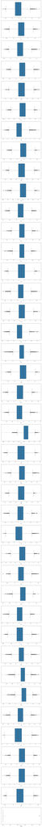

```python
plt.figure(figsize=(10,5*len(train.columns)))
for i,var in enumerate(train.columns):
    plt.subplot(len(train.columns),1,i+1)
    sns.boxplot(x=var,data=train,showmeans=True)
    #plt.tight_layout(pad=2)
plt.show()
```

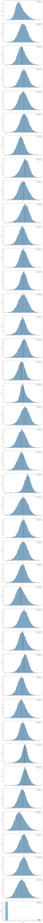

```python
plt.figure(figsize=(10,5*(len(train.columns))))
for i,var in enumerate(train.columns):
    mean_val = np.mean(train[var])
    median_val = np.median(train[var])
    plt.subplot(len(train.columns),1,i+1)
    sns.histplot(data=train,x=var,kde=True)
    plt.axvline(mean_val, color='red', linestyle='dashed', linewidth=2, label= f'Mean: {mean_val:.2f}')
    plt.axvline(median_val, color='green', linestyle='dashed', linewidth=2, label=f'Median: {median_val:.2f}')
    plt.tight_layout(pad=2)
    plt.legend()
plt.show()
```

Observations:

.The histograms indicate that the data for independent variables is approximately normally distributed with mean and median fairly close for most, further suggesting a normal distribution.

.The boxplots show dots outside of the whiskers, which represent outliers.

.The target variable is highly imbalanced, with a much larger count of the 0 class compared to the 1 class.

Data pre-processing

```python
train_df=train.copy()
test_df=test.copy()
```

```python
X=train_df.drop(['Target'],axis=1)
y=train_df['Target']
X.shape
```

```
(20000, 40)
```

```python
y.shape
```

```
(20000,)
```

```python
#splittin the dataset to training and validation set
X_train,X_val,y_train,y_val=train_test_split(X,y,test_size=0.25,random_state=42,stratify=y)
```

```python
X_test=test_df.drop(['Target'],axis=1)
y_test=test_df['Target']
```

```python
print("number of rows in training set",X_train.shape[0])
print("number of rows in validation set",X_val.shape[0])
print("number of rows in testing set",y_test.shape[0])
```

```
number of rows in training set 15000
number of rows in validation set 5000
number of rows in testing set 5000
```

X_train and y_train are now the subsets for training the model.

X_val and y_val are for validating the model during the hyperparameter tuning and model selection process.

X_test and y_test (from the original test dataset) are used strictly for the final evaluation of the model to assess its performance on unseen data.

Handling Missing Data

```python
from sklearn.impute import SimpleImputer
imputer=SimpleImputer(strategy='median')
X_train=pd.DataFrame(imputer.fit_transform(X_train),columns=X_train.columns)
X_val=pd.DataFrame(imputer.transform(X_val),columns=X_val.columns)
X_test=pd.DataFrame(imputer.transform(X_test),columns=X_test.columns)
```

```python
#checking for null values
print(X_test.isnull().sum().sum())
print(X_train.isnull().sum().sum())
print(X_val.isnull().sum().sum())
```

```
0
0
0
```

Normalizing data

```python
from sklearn.preprocessing import StandardScaler
scaler=StandardScaler()
X_train=pd.DataFrame(scaler.fit_transform(X_train),columns=X_train.columns)
X_val=pd.DataFrame(scaler.transform(X_val),columns=X_val.columns)
X_test=pd.DataFrame(scaler.transform(X_test),columns=X_test.columns)
```

```python
 X_train.head()
```

|  | V1 | V2 | V3 | V4 | V5 | V6 | V7 | V8 | V9 | V10 | ... | V31 | V32 | V33 | V34 | V35 | V36 | V37 | V38 | V39 | V40 |
| --- | --- | --- | --- | --- | --- | --- | --- | --- | --- | --- | --- | --- | --- | --- | --- | --- | --- | --- | --- | --- | --- |
| 0 | 0.815326 | 0.819216 | 1.155232 | 1.683876 | -0.809109 | -1.058666 | -0.530217 | -0.621713 | 2.223645 | -0.661473 | ... | -0.484596 | -0.411923 | -0.622671 | 0.297099 | 0.835311 | -0.998476 | -1.108025 | -0.675314 | -0.554808 | -1.245540 |
| 1 | -0.908564 | 1.543546 | 0.110795 | 0.171630 | 1.845924 | 0.701831 | -0.947385 | -0.758465 | 0.726852 | -1.505324 | ... | 0.418840 | 1.018185 | 2.254937 | -2.180389 | 0.228287 | -0.577491 | -0.481073 | 0.322147 | -0.071543 | 0.079400 |
| 2 | -0.240663 | 0.381205 | -0.099236 | 3.279277 | -0.989741 | -0.904170 | -2.139106 | -0.817453 | 2.943618 | -1.145958 | ... | -2.344722 | 0.887179 | 0.626018 | 0.027583 | 2.205000 | -2.720198 | -1.250290 | -0.545650 | -1.866315 | -2.727401 |
| 3 | 2.787158 | 0.625293 | 1.122528 | -1.290400 | -1.612682 | 0.648725 | 1.277901 | -1.078453 | 0.531820 | 0.350921 | ... | 0.283194 | -1.676315 | -0.544772 | -0.083839 | 0.942570 | -0.068777 | -0.940284 | 0.703151 | -0.069495 | 0.546015 |
| 4 | -1.082129 | -1.748742 | -0.472245 | -1.124665 | -0.127496 | 1.284054 | -1.729808 | -0.876888 | 0.223349 | 0.878982 | ... | -0.377019 | 0.033402 | 0.943227 | -0.394197 | -0.298619 | 1.045175 | 0.816123 | -0.269655 | 1.456644 | -0.296169 |

5 rows × 40 columns

Model Building

```python
#creating a funcion for metrics evaluation for predicted values
from sklearn.metrics import f1_score,accuracy_score,precision_score,recall_score,confusion_matrix,classification_report
def metrics_evaluation(model,predictors,target):
    y_pred=model.predict(predictors)
    acc=accuracy_score(target,y_pred)
    rec=recall_score(target,y_pred)
    f1=f1_score(target,y_pred)
    precision=precision_score(target,y_pred),
    metrics_df=pd.DataFrame({'Accuarcy': acc,'Recall': rec,'Precision ' : precision,'F1 score' :f1},index=[0])
    return metrics_df
```

```python
def confusion_mat(model,predictors,target):
    y_pred=model.predict(predictors)
    cm=confusion_matrix(target,y_pred)
    labels = np.asarray(
        [
            ["{0:0.0f}".format(item) + "\n{0:.2%}".format(item / cm.flatten().sum())]
            for item in cm.flatten()
        ]
    ).reshape(2, 2)
    plt.figure(figsize=(6,4))
    sns.heatmap(cm,annot=labels,fmt="")
    plt.xlabel("Predicted values")
    plt.ylabel("True values")
    plt.show()
```

Defining scorer for cross-validation and hyperparameter tuning .The goal here is to reduce the mainataince cost and to reduce the number of repairs, recall is choose to minimize the false negatives .So, use Recall as a scorer

```python
from sklearn import metrics
scorer=metrics.make_scorer(metrics.recall_score)
```

Model Building

```python
#model building on original data
models=[]
models.append(('Decision Tree',DecisionTreeClassifier(random_state=42)))
models.append(('Random Forest',RandomForestClassifier(random_state=42)))
models.append(('Logistic Regression',LogisticRegression(random_state=42,max_iter=1000)))
models.append(('Bagging classifier',BaggingClassifier(random_state=42)))
models.append(('Adaboost',AdaBoostClassifier(random_state=42)))
models.append(('Gradient Boosting',GradientBoostingClassifier(random_state=42)))

results_original=[]
names=[]

print("The cross validation recall scores:\n")
kfold=StratifiedKFold(n_splits=5,shuffle=True, random_state=42)
for name,model in models:
    res=cross_val_score(model,X_train,y_train, scoring=scorer, cv=kfold)
    results_original.append(res)
    names.append(name)
    print(name,":",res.mean())
print("recall score on validation set")
for name,model in models:
    model.fit(X_train,y_train)
    y_val_pred=model.predict(X_val)
    score=recall_score(y_val,y_val_pred)
    print(name,":",score)
```

[output not shown]

Recall is highest for RandomForest,followed by DEcision Tree ,Gradient boosting

Model Building with oversampling data using SMOTE

```python
sm = SMOTE(sampling_strategy=1, k_neighbors=5, random_state=1)
X_train_over, y_train_over = sm.fit_resample(X_train, y_train)
```

```python
print("before oversampling,count of label 0: ",y_train.value_counts()[0])
print("before oversampling,count of label 1: ",y_train.value_counts()[1])
print("after oversampling,count of label 0: ",y_train_over.value_counts()[0])
print("after oversampling,count of label 1: ",y_train_over.value_counts()[1])
```

```
before oversampling,count of label 0:  14167
before oversampling,count of label 1:  833
after oversampling,count of label 0:  14167
after oversampling,count of label 1:  14167
```

```python
#model building on oversampled data
models=[]
models.append(('Decision Tree',DecisionTreeClassifier(random_state=42)))
models.append(('Random Forest',RandomForestClassifier(random_state=42)))
models.append(('Logistic Regression',LogisticRegression(random_state=42,max_iter=1000)))
models.append(('Bagging classifier',BaggingClassifier(random_state=42)))
models.append(('Adaboost',AdaBoostClassifier(random_state=42)))
models.append(('Gradient Boosting',GradientBoostingClassifier(random_state=42)))

results_over_sampled=[]
names=[]

print("The cross validation recall scores:\n")
kfold=StratifiedKFold(n_splits=5,shuffle=True, random_state=42)
for name,model in models:
    res=cross_val_score(model,X_train_over,y_train_over, scoring=scorer, cv=kfold)
    results_over_sampled.append(res)
    names.append(name)
    print(name,":",res.mean())
print("recall score on validation set")
for name,model in models:
    model.fit(X_train_over,y_train_over)
    y_val_pred=model.predict(X_val)
    score=recall_score(y_val,y_val_pred)
    print(name,":",score)
```

```
The cross validation recall scores:

Decision Tree : 0.9714126108738104
Random Forest : 0.9834825766790779
Logistic Regression : 0.8764032930770302
Bagging classifier : 0.9748006967983198
Adaboost : 0.8845205002738916
Gradient Boosting : 0.9226372765179814
recall score on validation set
Decision Tree : 0.7978339350180506
Random Forest : 0.8700361010830325
Logistic Regression : 0.8772563176895307
Bagging classifier : 0.8303249097472925
Adaboost : 0.8808664259927798
Gradient Boosting : 0.8989169675090253
```

After oversampling using SMOTE,the models performance on training data has increased but under performed on validation set,except for logistic regresssion ,Adabbost and Gradient boosting

Model Building with Undersampled Data

```python
us=RandomUnderSampler(random_state=1, sampling_strategy=1)
X_train_un,y_train_un=us.fit_resample(X_train,y_train)
```

```python
print("before undersampling,count of label 0: ",y_train.value_counts()[0])
print("before undersampling,count of label 1: ",y_train.value_counts()[1])
print("after undersampling,count of label 0: ",y_train_un.value_counts()[0])
print("after undersampling,count of label 1: ",y_train_un.value_counts()[1])
```

```
before undersampling,count of label 0:  14167
before undersampling,count of label 1:  833
after undersampling,count of label 0:  833
after undersampling,count of label 1:  833
```

```python
#model building on oversampled data
models=[]
models.append(('Decision Tree',DecisionTreeClassifier(random_state=42)))
models.append(('Random Forest',RandomForestClassifier(random_state=42)))
models.append(('Logistic Regression',LogisticRegression(random_state=42,max_iter=1000)))
models.append(('Bagging classifier',BaggingClassifier(random_state=42)))
models.append(('Adaboost',AdaBoostClassifier(random_state=42)))
models.append(('Gradient Boosting',GradientBoostingClassifier(random_state=42)))

results_under_sampled=[]
names=[]

print("The cross validation recall scores:\n")
kfold=StratifiedKFold(n_splits=5,shuffle=True, random_state=42)
for name,model in models:
    res=cross_val_score(model,X_train_un,y_train_un, scoring=scorer, cv=kfold)
    results_under_sampled.append(res)
    names.append(name)
    print(name,":",res.mean())
print("\nrecall score on validation set\n")
for name,model in models:
    model.fit(X_train_un,y_train_un)
    y_val_pred=model.predict(X_val)
    score=recall_score(y_val,y_val_pred)
    print(name,":",score)
```

```
The cross validation recall scores:

Decision Tree : 0.8450977562946397
Random Forest : 0.8991342615972874
Logistic Regression : 0.8535242767477094
Bagging classifier : 0.8655003246519011
Adaboost : 0.8655003246519011
Gradient Boosting : 0.8907221701175961

recall score on validation set

Decision Tree : 0.8664259927797834
Random Forest : 0.9097472924187726
Logistic Regression : 0.8772563176895307
Bagging classifier : 0.8808664259927798
Adaboost : 0.8772563176895307
Gradient Boosting : 0.8989169675090253
```

The recall is highest for random forest,followed by gradient boosting,bagging classifier and Adaboost Also there is less overfitting compared to SMOTE

Hyperparameter Tuning

Model Selection for Hyperparameter Tuning Top 3 models providing the highest Recall scores on both cross-validation and validation datasets : RandomForest GradientBoosting AdaBoost

Hyperparameter Tuning of Random Forest on Original Data

```python
rf_org=RandomForestClassifier(random_state=42)
param_grid={
    "n_estimators": [200,250,300],
    "min_samples_leaf": np.arange(1, 4),
    "max_features": [np.arange(0.3, 0.6, 0.1),'sqrt'],
    "max_samples": np.arange(0.4, 0.7, 0.1)
}
rscv=RandomizedSearchCV(estimator=rf_org,
                        param_distributions=param_grid,
                        scoring=scorer,
                        n_iter=10,  # Number of random combinations to test
                        cv=5,  # 5-fold cross-validation
                        random_state=42)
rscv.fit(X_train,y_train)

print("the best parameters are:",rscv.best_params_)
rf_org=rscv.best_estimator_
rf_org.fit(X_train,y_train)
```

[output not shown]

```
the best parameters are: {'n_estimators': 250, 'min_samples_leaf': np.int64(2), 'max_samples': np.float64(0.6), 'max_features': 'sqrt'}
```

```
RandomForestClassifier(max_samples=np.float64(0.6),
                       min_samples_leaf=np.int64(2), n_estimators=250,
                       random_state=42)
```

```python
rf_org_train=metrics_evaluation(rf_org,X_train,y_train)
print("\nthe performance on training set\n",rf_org_train)
rf_org_val=metrics_evaluation(rf_org,X_val,y_val)
print("\nthe performance on validation set\n",rf_org_val)
```

```
the performance on training set
    Accuarcy    Recall  Precision   F1 score
0  0.991133  0.842737    0.997159  0.913468

the performance on validation set
    Accuarcy    Recall  Precision   F1 score
0    0.9844  0.729242    0.985366  0.838174
```

```python
confusion_mat(rf_org,X_train,y_train)
```

[output not shown]

```python
confusion_mat(rf_org,X_val,y_val)
```

[output not shown]

Hyperparameter Tuning of Random Forest on Oversampled Data

```python
rf_over=RandomForestClassifier(random_state=42)
param_grid={
    "n_estimators": [200,250,300],
    "min_samples_leaf": np.arange(1, 4),
    "max_features": [np.arange(0.3, 0.6, 0.1),'sqrt'],
    "max_samples": np.arange(0.4, 0.7, 0.1)
}
rscv=RandomizedSearchCV(estimator=rf_over,param_distributions=param_grid,scoring=scorer,n_iter=10,cv=5,random_state=42)
rscv.fit(X_train_over,y_train_over)
print("the best parameters are",rscv.best_params_)
rf_over=rscv.best_estimator_
rf_over.fit(X_train_over,y_train_over)
```

[output not shown]

```
the best parameters are {'n_estimators': 250, 'min_samples_leaf': np.int64(2), 'max_samples': np.float64(0.6), 'max_features': 'sqrt'}
```

```
RandomForestClassifier(max_samples=np.float64(0.6),
                       min_samples_leaf=np.int64(2), n_estimators=250,
                       random_state=42)
```

```python
rf_over_train=metrics_evaluation(rf_over,X_train,y_train)
print("\n the performance on training set:\n",rf_over_train)
rf_over_val=metrics_evaluation(rf_over,X_val,y_val)
print("\n the performance on validation set:\n",rf_over_val)
```

```
 the performance on training set:
    Accuarcy  Recall  Precision   F1 score
0    0.9994     1.0    0.989311  0.994627

 the performance on validation set:
    Accuarcy    Recall  Precision   F1 score
0    0.9884  0.877256    0.910112  0.893382
```

```python
confusion_mat(rf_over,X_train,y_train)
```

[output not shown]

```python
confusion_mat(rf_over,X_val,y_val)
```

[output not shown]

```python
Hyperparameter Tuning of Random Forest on undersampled Data
```

```python
rf_under=RandomForestClassifier(random_state=42)
param_grid={
    "n_estimators": [200,250,300],
    "min_samples_leaf": np.arange(1, 4),
    "max_features": [np.arange(0.3, 0.6, 0.1),'sqrt'],
    "max_samples": np.arange(0.4, 0.7, 0.1)
}
rscv=RandomizedSearchCV(estimator=rf_under,n_iter=10,cv=5,random_state=42,scoring=scorer,param_distributions=param_grid)
rscv.fit(X_train_un,y_train_un)
print("the best parameters are",rscv.best_params_)
rf_under=rscv.best_estimator_
rf_under.fit(X_train_un,y_train_un)
```

[output not shown]

```
the best parameters are {'n_estimators': 250, 'min_samples_leaf': np.int64(2), 'max_samples': np.float64(0.6), 'max_features': 'sqrt'}
```

```
RandomForestClassifier(max_samples=np.float64(0.6),
                       min_samples_leaf=np.int64(2), n_estimators=250,
                       random_state=42)
```

```python
rf_under_train=metrics_evaluation(rf_under,X_train,y_train)
print("the performance on training set\n",rf_under_train)
rf_under_val=metrics_evaluation(rf_under,X_val,y_val)
print("the performance on validation set\n",rf_under_val)
```

```
the performance on training set
    Accuarcy    Recall  Precision   F1 score
0  0.933733  0.943577    0.453549  0.612627
the performance on validation set
    Accuarcy    Recall  Precision   F1 score
0    0.9292  0.909747    0.433735  0.587413
```

```python
confusion_mat(rf_under,X_train,y_train)
```

[output not shown]

```python
confusion_mat(rf_under,X_val,y_val)
```

[output not shown]

Hyperparameter Tuning of Gradient Boosting on Original Data

```python
gb_org=GradientBoostingClassifier(random_state=42)
param_grid={
    "n_estimators": np.arange(100,150,25),
    "learning_rate": [0.2, 0.05, 1],
    "subsample":[0.5,0.7],
    "max_features":[0.5,0.7] }
gbcv=RandomizedSearchCV(estimator=gb_org,param_distributions=param_grid,scoring=scorer,cv=5,random_state=42)
gbcv.fit(X_train,y_train)
print("the best Parameters are",gbcv.best_params_)
gb_org=gbcv.best_estimator_
gb_org.fit(X_train,y_train)
```

[output not shown]

```python
gb_org_train=metrics_evaluation(gb_org,X_train,y_train)
print("\nthe performance on training set\n",gb_org_train)
gb_org_val=metrics_evaluation(gb_org,X_val,y_val)
print("\nthe performance on validation set\n",gb_org_val)
```

```
the performance on training set
    Accuarcy   Recall  Precision   F1 score
0    0.9878  0.80072    0.975146  0.879367

the performance on validation set
    Accuarcy    Recall  Precision   F1 score
0    0.9826  0.722022    0.952381  0.821355
```

```python
confusion_mat(gb_org,X_train,y_train)
```

[output not shown]

```python
confusion_mat(gb_org,X_val,y_val)
```

[output not shown]

Hyperparameter Tuning of Gradient Boosting on Oversampled Data

```python
gb_over=GradientBoostingClassifier(random_state=42)
param_grid={
     "n_estimators": np.arange(100,150,25),
    "learning_rate": [0.2, 0.05, 1],
    "subsample":[0.5,0.7],
    "max_features":[0.5,0.7] }
gbcv=RandomizedSearchCV(estimator=gb_over,param_distributions=param_grid,scoring=scorer,cv=5,random_state=42)
gbcv.fit(X_train_over,y_train_over)
print("the best parameters are",gbcv.best_params_)
gb_over=gbcv.best_estimator_
gb_over.fit(X_train_over,y_train_over)
```

```
the best parameters are {'subsample': 0.7, 'n_estimators': np.int64(100), 'max_features': 0.7, 'learning_rate': 1}
```

```
GradientBoostingClassifier(learning_rate=1, max_features=0.7,
                           n_estimators=np.int64(100), random_state=42,
                           subsample=0.7)
```

```python
gb_over_train=metrics_evaluation(gb_over,X_train,y_train)
print("\nthe performance on training set:\n",gb_over_train)
gb_over_val=metrics_evaluation(gb_over,X_val,y_val)
print("\nthe performance on validation set\n",gb_over_val)
```

```
the performance on training set:
    Accuarcy    Recall  Precision   F1 score
0  0.985267  0.977191    0.801181  0.880476

the performance on validation set
    Accuarcy    Recall  Precision   F1 score
0    0.9634  0.902527    0.615764  0.732064
```

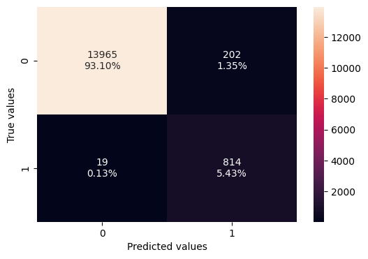

```python
confusion_mat(gb_over,X_train,y_train)
```

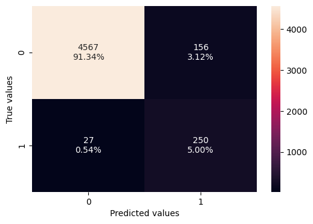

```python
confusion_mat(gb_over,X_val,y_val)
```

Hyperparameter Tuning of Gradient Boosting on underSampled Data

```python
gb_under=GradientBoostingClassifier(random_state=42)
param_grid={
     "n_estimators": np.arange(100,150,25),
    "learning_rate": [0.2, 0.05, 1],
    "subsample":[0.5,0.7],
    "max_features":[0.5,0.7] }
gbcv=RandomizedSearchCV(estimator=gb_under,param_distributions=param_grid,scoring=scorer,cv=5,random_state=42)
gbcv.fit(X_train_un,y_train_un)
print("the best parameters are",gbcv.best_params_)
gb_under=gbcv.best_estimator_
gb_under.fit(X_train_un,y_train_un)
```

```
the best parameters are {'subsample': 0.7, 'n_estimators': np.int64(100), 'max_features': 0.7, 'learning_rate': 0.2}
```

```
GradientBoostingClassifier(learning_rate=0.2, max_features=0.7,
                           n_estimators=np.int64(100), random_state=42,
                           subsample=0.7)
```

```python
gb_under_train=metrics_evaluation(gb_under,X_train,y_train)
print("\nthe performance on training set:\n",gb_under_train)
gb_under_val=metrics_evaluation(gb_under,X_val,y_val)
print("the performance on validation set\n",gb_under_val)
```

```
the performance on training set:
    Accuarcy    Recall  Precision   F1 score
0  0.916933  0.983193    0.399317  0.567961
the performance on validation set
    Accuarcy    Recall  Precision   F1 score
0    0.9118  0.909747    0.377246  0.533333
```

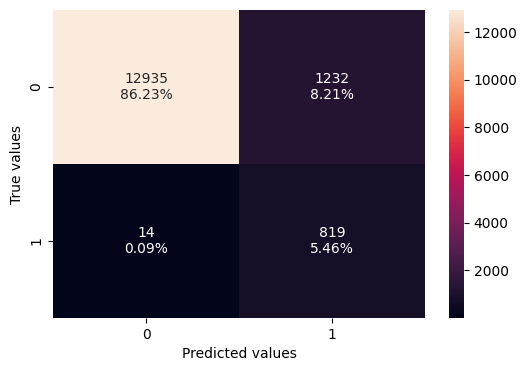

```python
confusion_mat(gb_under,X_train,y_train)
```

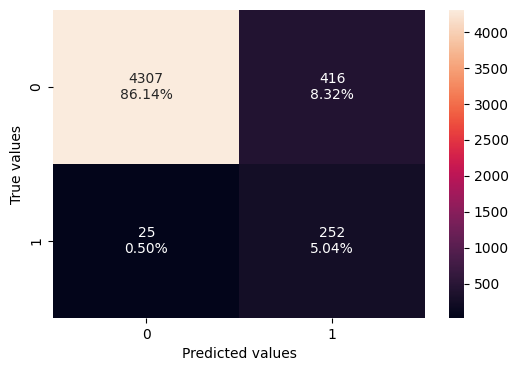

```python
confusion_mat(gb_under,X_val,y_val)
```

Hyperparameter Tuning of Ada Boost on original Data

```python
ab=AdaBoostClassifier(random_state=42)
param_grid={
    "n_estimators": [100, 150, 200],
    "learning_rate": [0.2, 0.05],
    "estimator": [DecisionTreeClassifier(max_depth=1, random_state=1),
                       DecisionTreeClassifier(max_depth=2, random_state=1),
                       DecisionTreeClassifier(max_depth=3, random_state=1) ] }
adcv=RandomizedSearchCV(estimator=ab,param_distributions=param_grid,scoring=scorer,cv=5,random_state=42)
adcv.fit(X_train,y_train)

# Extracting best parameters
best_parameters=adcv.best_params_

# Creating a new pipline of AdaBoost Classifier with the best parameters
ab_org=AdaBoostClassifier(**best_parameters,random_state=42)
ab_org.fit(X_train,y_train)
```

```
AdaBoostClassifier(estimator=DecisionTreeClassifier(max_depth=3,
                                                    random_state=1),
                   learning_rate=0.2, n_estimators=150, random_state=42)
```

```python
ab_org_train=metrics_evaluation(ab_org,X_train,y_train)
print("\nThe performance on training set\n:",ab_org_train)
ab_org_val=metrics_evaluation(ab_org,X_val,y_val)
print("\nthe performance on valiation set\n",ab_org_val)
```

```
The performance on training set
:    Accuarcy    Recall  Precision   F1 score
0  0.983533  0.715486    0.983498  0.828353

the performance on valiation set
    Accuarcy    Recall  Precision   F1 score
0     0.982  0.700361    0.965174  0.811715
```

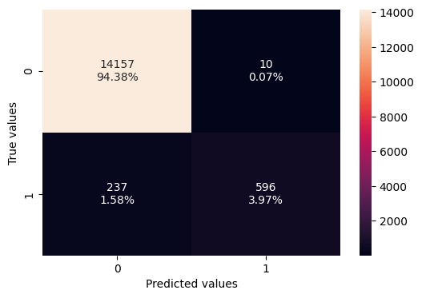

```python
confusion_mat(ab_org,X_train,y_train)
```

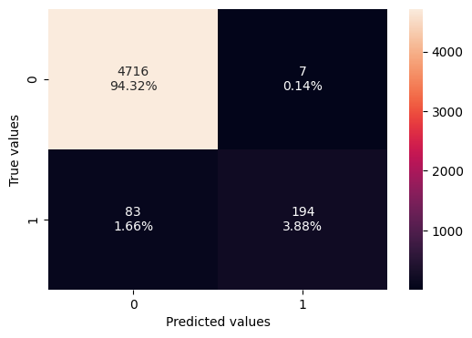

```python
confusion_mat(ab_org,X_val,y_val)
```

Hyperparameter Tuning of Ada Boost on oversampled Data

```python
ab=AdaBoostClassifier(random_state=42)
param_grid={
    "n_estimators": [100, 150, 200],
    "learning_rate": [0.2, 0.05],
    "estimator": [DecisionTreeClassifier(max_depth=1, random_state=1),
                       DecisionTreeClassifier(max_depth=2, random_state=1),
                       DecisionTreeClassifier(max_depth=3, random_state=1), ] }
adcv=RandomizedSearchCV(estimator=ab,param_distributions=param_grid,scoring=scorer,cv=5,random_state=42,n_jobs=-1)
adcv.fit(X_train_over,y_train_over)

# Extracting best parameters
best_parameters=adcv.best_params_

# Creating a new pipline of AdaBoost Classifier with the best parameters
ab_over=AdaBoostClassifier(**best_parameters,random_state=42)
ab_over.fit(X_train_over,y_train_over)
```

```
AdaBoostClassifier(estimator=DecisionTreeClassifier(max_depth=3,
                                                    random_state=1),
                   learning_rate=0.2, n_estimators=150, random_state=42)
```

```python
ab_over_train=metrics_evaluation(ab_over,X_train,y_train)
print("\nThe performance on training set\n:",ab_over_train)
ab_over_val=metrics_evaluation(ab_over,X_val,y_val)
print("\nthe performance on valiation set\n",ab_over_val)
```

```
The performance on training set
:    Accuarcy    Recall  Precision   F1 score
0  0.946733  0.903962    0.511549  0.653362

the performance on valiation set
    Accuarcy    Recall  Precision   F1 score
0    0.9408  0.877256    0.481188  0.621483
```

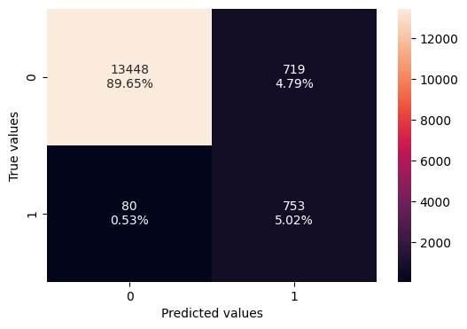

```python
confusion_mat(ab_over,X_train,y_train)
```

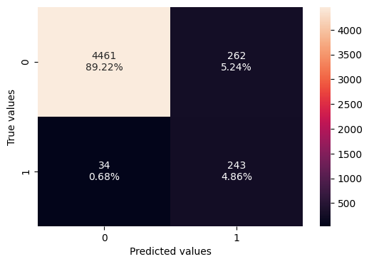

```python
confusion_mat(ab_over,X_val,y_val)
```

Hyperparameter Tuning of Ada Boost on undersampled Data

```python
ab=AdaBoostClassifier(random_state=42)
param_grid={
    "n_estimators": [100, 150, 200],
    "learning_rate": [0.2, 0.05],
    "estimator": [DecisionTreeClassifier(max_depth=1, random_state=1),
                       DecisionTreeClassifier(max_depth=2, random_state=1),
                       DecisionTreeClassifier(max_depth=3, random_state=1), ] }
adcv=RandomizedSearchCV(estimator=ab,param_distributions=param_grid,scoring=scorer,cv=5,random_state=42)
adcv.fit(X_train_un,y_train_un)

# Extracting best parameters
best_parameters=adcv.best_params_

ab_under=AdaBoostClassifier(n_estimators=best_parameters['n_estimators'],
                            learning_rate=best_parameters['learning_rate'],
                            estimator=best_parameters['estimator'])

ab_under.fit(X_train_un,y_train_un)
```

```
AdaBoostClassifier(estimator=DecisionTreeClassifier(max_depth=3,
                                                    random_state=1),
                   learning_rate=0.2, n_estimators=150)
```

```python
best_parameters
```

```
{'n_estimators': 150,
 'learning_rate': 0.2,
 'estimator': DecisionTreeClassifier(max_depth=3, random_state=1)}
```

```python
ab_under_train=metrics_evaluation(ab_under,X_train,y_train)
print("\nThe performance on training set\n:",ab_under_train)
ab_under_val=metrics_evaluation(ab_under,X_val,y_val)
print("\nthe performance on valiation set\n",ab_under_val)
```

```
The performance on training set
:    Accuarcy    Recall  Precision   F1 score
0    0.9158  0.923169    0.390752   0.54909

the performance on valiation set
    Accuarcy    Recall  Precision   F1 score
0    0.9138  0.906137    0.382622  0.538049
```

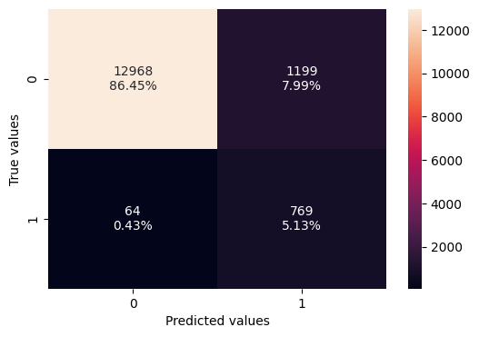

```python
confusion_mat(ab_under,X_train,y_train)
```

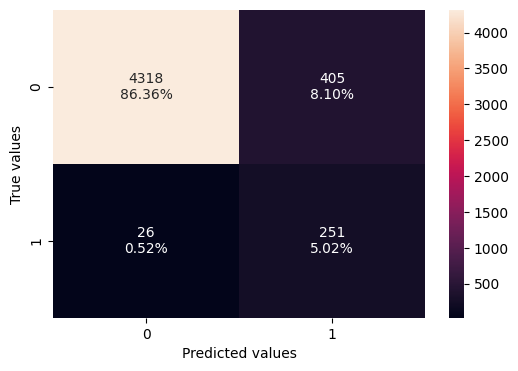

```python
confusion_mat(ab_under,X_val,y_val)
```

Model Performance Comparison

```python
 #Training performance comparison

train_comp_df = pd.concat(
    [
        rf_org_train.T,
        gb_org_train.T,
        ab_org_train.T,

        rf_over_train.T,
        gb_over_train.T,
        ab_over_train.T,

        rf_under_train.T,
        gb_under_train.T,
        ab_under_train.T,

    ],
    axis=1,
)
train_comp_df.columns = [
       'rf_train_perf_orig',
       'gbm_train_perf_orig',
       'ada_train_perf_orig',

       'rf_train_perf_over',
       'gbm_train_perf_over',
       'ada_train_perf_over',

       'rf_train_perf_un',
       'gbm_train_perf_un',
       'ad_train_perf_un',
]
print("Training performance comparison:")
train_comp_df
```

```
Training performance comparison:
```

|  | rf_train_perf_orig | gbm_train_perf_orig | ada_train_perf_orig | rf_train_perf_over | gbm_train_perf_over | ada_train_perf_over | rf_train_perf_un | gbm_train_perf_un | ad_train_perf_un |
| --- | --- | --- | --- | --- | --- | --- | --- | --- | --- |
| Accuarcy | 0.991133 | 0.987800 | 0.983533 | 0.999400 | 0.985267 | 0.946733 | 0.933733 | 0.916933 | 0.915800 |
| Recall | 0.842737 | 0.800720 | 0.715486 | 1.000000 | 0.977191 | 0.903962 | 0.943577 | 0.983193 | 0.923169 |
| Precision | 0.997159 | 0.975146 | 0.983498 | 0.989311 | 0.801181 | 0.511549 | 0.453549 | 0.399317 | 0.390752 |
| F1 score | 0.913468 | 0.879367 | 0.828353 | 0.994627 | 0.880476 | 0.653362 | 0.612627 | 0.567961 | 0.549090 |

```python
# Validation performance comparison

val_comp_df = pd.concat(
    [
        rf_org_val.T,
        gb_org_val.T,
        ab_org_val.T,

        rf_over_val.T,
        gb_over_val.T,
        ab_over_val.T,

        rf_under_val.T,
        gb_under_val.T,
        ab_under_val.T,
    ],
    axis=1,
)
val_comp_df.columns = [
       'rf_val_perf_orig',
       'gbm_val_perf_orig',
       'ada_val_perf_orig',

       'rf_val_perf_over',
       'gbm_val_perf_over',
       'ada_val_perf_over',

       'rf_val_perf_un',
       'gbm_val_perf_un',
       'ada_val_perf_un',
]
print("Validation performance comparison:")
val_comp_df
```

```
Validation performance comparison:
```

|  | rf_val_perf_orig | gbm_val_perf_orig | ada_val_perf_orig | rf_val_perf_over | gbm_val_perf_over | ada_val_perf_over | rf_val_perf_un | gbm_val_perf_un | ada_val_perf_un |
| --- | --- | --- | --- | --- | --- | --- | --- | --- | --- |
| Accuarcy | 0.984400 | 0.982600 | 0.982000 | 0.988400 | 0.963400 | 0.940800 | 0.929200 | 0.911800 | 0.913800 |
| Recall | 0.729242 | 0.722022 | 0.700361 | 0.877256 | 0.902527 | 0.877256 | 0.909747 | 0.909747 | 0.906137 |
| Precision | 0.985366 | 0.952381 | 0.965174 | 0.910112 | 0.615764 | 0.481188 | 0.433735 | 0.377246 | 0.382622 |
| F1 score | 0.838174 | 0.821355 | 0.811715 | 0.893382 | 0.732064 | 0.621483 | 0.587413 | 0.533333 | 0.538049 |

Final Model Selection

```python
# Check the performance of the final model on the test data
ada_test = metrics_evaluation(ab_under, X_test, y_test)
ada_test
```

|  | Accuarcy | Recall | Precision | F1 score |
| --- | --- | --- | --- | --- |
| 0 | 0.9376 | 0.829787 | 0.46988 | 0.6 |

```python
# Check the performance of the final model on the test data
gb_test = metrics_evaluation(gb_under, X_test, y_test)
gb_test
```

|  | Accuarcy | Recall | Precision | F1 score |
| --- | --- | --- | --- | --- |
| 0 | 0.5312 | 0.932624 | 0.101623 | 0.183275 |

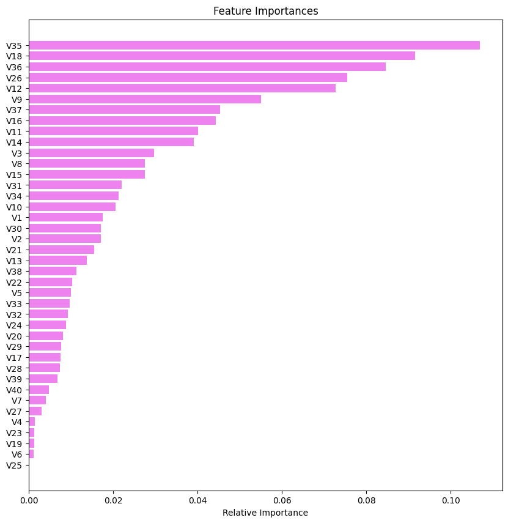

```python
feature_names = X_train.columns
importances = ab_under.feature_importances_
indices = np.argsort(importances)

plt.figure(figsize=(10, 10))
plt.title("Feature Importances")
plt.barh(range(len(indices)), importances[indices], color="violet", align="center")
plt.yticks(range(len(indices)), [feature_names[i] for i in indices])
plt.xlabel("Relative Importance")
plt.show()
```

The significant features are: V35,V18,V36

Pipelines to build the final model

```python
pipe=Pipeline(
    steps=[
        ('Imputer',SimpleImputer(strategy='median')),
        ('Normalization',StandardScaler()),
        ('AdaBoost',AdaBoostClassifier
          (
              n_estimators= 150,
              learning_rate= 0.2,
              estimator= DecisionTreeClassifier(max_depth=3, random_state=1),
          ),
        )
    ]
)
```

```python
pipe.steps
```

```
[('Imputer', SimpleImputer(strategy='median')),
 ('Normalization', StandardScaler()),
 ('AdaBoost',
  AdaBoostClassifier(estimator=DecisionTreeClassifier(max_depth=3,
                                                      random_state=1),
                     learning_rate=0.2, n_estimators=150))]
```

```python
pipe.fit(X_train_un,y_train_un)
```

```
Pipeline(steps=[('Imputer', SimpleImputer(strategy='median')),
                ('Normalization', StandardScaler()),
                ('AdaBoost',
                 AdaBoostClassifier(estimator=DecisionTreeClassifier(max_depth=3,
                                                                     random_state=1),
                                    learning_rate=0.2, n_estimators=150))])
```

```python
metrics_evaluation(pipe, X_test, y_test)
```

|  | Accuarcy | Recall | Precision | F1 score |
| --- | --- | --- | --- | --- |
| 0 | 0.9378 | 0.833333 | 0.470942 | 0.601793 |

```python
metrics_evaluation(pipe, X_val, y_val)
```

|  | Accuarcy | Recall | Precision | F1 score |
| --- | --- | --- | --- | --- |
| 0 | 0.9138 | 0.906137 | 0.382622 | 0.538049 |

Business Insights and Conclusions

.The important features are V35,V18,V36 .The company should focus on improving the important features so they can reduce the number of failures and the amount of money spent on repairs and replacements

```python
import nbconvert
```

```python
!jupyter nbconvert Renewind.ipynb --to HTML
```